# SAA Overlay Workflow

Build → Classify → Fingerprint → Backtest — End-to-End Guide

ETF Intelligence Project

2026-04-04

# 1 Purpose

This workflow answers a single practical question:

> Given a binary SAA (two tickers + target weights), which assets from the full universe best **enhance** its return or **stabilise** its drawdown — and how much does adding each one improve the portfolio?

It runs five steps automatically:

| Step | Function | Output |
| --- | --- | --- |
| 1 | `build_saa_ret()` | Daily-rebalanced SAA return series → injected into `xts_ret` |
| 2 | `rank_enhancers()` / `rank_stabilizers()` | Top 5 candidates ranked by criterion |
| 3 | `overlay_summary_heatmap()` | Two-panel ranking table |
| 4 | `fingerprint_candidates()` | `screen_ticker()` fingerprint per candidate |
| 5 | `backtest_ls_overlay()` | Wealth + L/S spread + stats for each set |

All steps are orchestrated by a single call to `run_saa_overlay_workflow()`.

# 2 Design Choices (v1)

| Dimension | v1 Choice | Rationale |
| --- | --- | --- |
| SAA type | Binary (two tickers) | Simplest starting point |
| SAA rebalancing | Daily — $r_{\text{SAA}} = w_1 r_1 + w_2 r_2$ | Constant-weight; no loop needed |
| SAA injection | Added to `xts_ret` as `"saa{W1}{W2}"` | Allows `classify_universe(baseline = "saa6040")` with no code changes |
| Enhancer ranking | `full_ir` — information ratio over full period | Single interpretable number; already computed by `classify_universe()` |
| Stabilizer ranking | `dd_reduction` — MaxDD reduction in pp | Most direct measure of the overlay’s defensive value |
| Universe | Full Sovereign Universe (default); pass `universe` vector to restrict | Consistent with existing `classify_universe()` interface |
| Overlay formula | **Option B**: $r_{\text{ov}} = r_{\text{SAA}} + \alpha (r_{\text{candidate}} - r_{\text{SAA}})$ | Keeps pure L/S framing; maps to existing `build_ls_portfolio()` pattern |
| Backtest | Long overlay-SAA / Short original-SAA | Spread PnL = $\alpha (r_{\text{candidate}} - r_{\text{SAA}})$ |
| Fingerprint | `screen_ticker()` per candidate + condensed summary | Reuses existing 7-panel fingerprint infrastructure |

# 3 Overlay Formula

$$r_t^{\text{overlay}} = r_t^{\text{SAA}}
+ \alpha \times \left(r_t^{\text{candidate}} -
r_t^{\text{SAA}}\right)$$

Expanding:

$$= (1 - \alpha)\, r_t^{\text{SAA}} +
\alpha\, r_t^{\text{candidate}}$$

So the overlay portfolio is simply **$(1-\alpha)$ of SAA plus $\alpha$ of the candidate** — but the L/S framing makes clear what you are *adding*: a spread trade on top of unchanged SAA exposure.

**L/S spread daily PnL:**

$$\text{spread}_t = \alpha \times
\left(r_t^{\text{candidate}} - r_t^{\text{SAA}}\right)$$

Cumulative spread > 1 means the candidate is beating the SAA over that period.

# 4 Function Reference

## 4.1 `build_saa_ret()`

```r
build_saa_ret(
  ticker1,          # character — first component (e.g. "SPY")
  ticker2,          # character — second component (e.g. "IEF")
  w1,               # numeric  — target weight for ticker1 (e.g. 0.60)
  w2  = 1 - w1,     # numeric  — complement (default)
  name = NULL       # character — column name; default "saa{W1}{W2}" e.g. "saa6040"
)
```

**What it does:**

1. Computes $r_{\text{SAA}, t} = w_1 r_{1,t} + w_2 r_{2,t}$ over the common date range.
2. Assigns the result to the global `xts_ret` as a new column.
3. Prints a one-line confirmation with the column name, date range, and day count.

If the column already exists, it is silently skipped (safe to re-run).

## 4.2 `rank_enhancers()` / `rank_stabilizers()`

```r
rank_enhancers(
  baseline,           # SAA column name in xts_ret (e.g. "saa6040")
  universe  = NULL,   # character vector; NULL = all cols except baseline
  top_n     = 5L,
  overlay_w = 0.10,   # overlay weight passed to screen_ticker() inside classify_universe()
  verbose   = FALSE
)
```

Both functions call `classify_universe(baseline = saa_name, ...)` which runs `screen_ticker()` for every ticker in the universe and returns the full classification table. Then:

- **`rank_enhancers()`** filters to `classification %in% c("Enhancer","Dual")`, sorts descending by `full_ir`, returns top N.
- **`rank_stabilizers()`** filters to `classification %in% c("Stabilizer","Dual")`, sorts descending by `dd_reduction`, returns top N.

**Returned columns:** `ticker`, `classification`, `trigger_type`, `hedge_type`, `full_ir`, `dd_reduction`, `ins_ratio`, `fall_corr`, `n_days`.

**Key metrics:**

| Metric | Definition | Units |
| --- | --- | --- |
| `full_ir` | Information ratio: excess Ann Ret / tracking error vs SAA | ratio |
| `dd_reduction` | Reduction in SAA MaxDD when overlay_w of candidate is added | pp (percentage points) |
| `ins_ratio` | dd_reduction / return_drag — insurance per unit of cost | ratio |
| `fall_corr` | Correlation with SAA *during Fall regimes only* | −1 to +1 |

## 4.3 `fingerprint_candidates()`

```r
fingerprint_candidates(
  tickers,            # character vector — tickers to screen
  baseline,           # SAA column name
  overlay_w = 0.10,
  print_plot = TRUE,  # print 7-panel fingerprint to Plots pane
  ...                 # additional args passed to screen_ticker()
)
```

Loops `screen_ticker(tk, baseline = saa_name)` for each ticker. Returns a named list; each element is a `screen_ticker()` result:

```r
res$enh_screens[["GLD"]]$plot        # 7-panel fingerprint plot
res$enh_screens[["GLD"]]$enhancer    # enhancer verdict tibble
res$enh_screens[["GLD"]]$stabilizer  # stabilizer verdict tibble
```

Set `print_fingerprints = FALSE` in `run_saa_overlay_workflow()` to skip this step during exploratory runs (it is the slowest step).

## 4.4 `overlay_summary_heatmap()`

```r
overlay_summary_heatmap(enh_tbl, stab_tbl, baseline = "")
```

Two-panel patchwork figure:

- **Left — Enhancers:** Rank | Ticker | Class | Trigger | Full IR (traffic-light: green = #1, red = #N)
- **Right — Stabilizers:** Rank | Ticker | Class | Hedge | DD Red (pp) | Ins Ratio | Fall ρ

## 4.5 `backtest_ls_overlay()`

```r
backtest_ls_overlay(
  saa_name,                           # SAA column in xts_ret
  tickers,                            # candidate tickers
  pct,                                # α — overlay fraction
  type = c("enhancer","stabilizer")   # controls colour palette and title
)
```

Returns a list with four elements:

| Element | Content |
| --- | --- |
| `$fig` | Patchwork figure: P1 wealth + P2 spread + P3 stats table |
| `$stats` | Tibble: Ann Ret / Ann Vol / Max DD / Sharpe / Calmar for SAA + each overlay |
| `$ret` | xts: SAA + all overlay return series on common dates |
| `$spread` | data.frame: daily cumulative spread for each candidate |

## 4.6 `run_saa_overlay_workflow()` — master orchestrator

```r
run_saa_overlay_workflow(
  ticker1,
  ticker2,
  w1,
  w2                 = 1 - w1,
  saa_name           = NULL,    # auto: "saa{W1}{W2}"
  universe           = NULL,    # NULL = full Sovereign Universe
  top_n              = 5L,
  enh_pct            = 0.10,    # α for enhancer overlays
  stab_pct           = 0.10,    # α for stabilizer overlays
  overlay_w          = 0.10,    # classification overlay weight
  print_fingerprints = TRUE,    # FALSE = skip screen_ticker() (faster)
  verbose            = FALSE
)
```

Runs all five steps in sequence and returns a named list:

```r
res$saa_name       # "saa6040"
res$enhancers      # tibble — top 5 enhancers with metrics
res$stabilizers    # tibble — top 5 stabilizers with metrics
res$summary_fig    # patchwork heatmap (Step 3)
res$enh_screens    # named list of screen_ticker() results (Step 4)
res$stab_screens   # named list of screen_ticker() results (Step 4)
res$enh_backtest   # list(fig, stats, ret, spread) — enhancer backtest
res$stab_backtest  # list(fig, stats, ret, spread) — stabilizer backtest
```

# 5 Live Example — SPY / IEF 60/40

## 5.1 Run the full workflow

```r
res <- run_saa_overlay_workflow(
  ticker1  = "SPY",
  ticker2  = "IEF",
  w1       = 0.60,
  enh_pct  = 0.10,
  stab_pct = 0.10,
  print_fingerprints = FALSE   # set TRUE to add screen_ticker() fingerprints
)
```

```
##
## ══════════════════════════════════════════════════════════════════════
##   SAA Overlay Workflow  (v1)
##   SPY / IEF  |  w1=60%  w2=40%  |  enhα=10%  stabα=10%
## ══════════════════════════════════════════════════════════════════════
##
## ── Step 1: Build SAA return series
```

```
##
## ── Step 2a: Rank enhancers vs saa6040
```

```
##
## ── Step 2b: Rank stabilizers vs saa6040
```

```
##
##   Enhancers:   NVDA  SMH  XLK  QQQ  AAPL
##   Stabilizers: NVDA  BA  WCLD  IPO  CRM
##
## ── Step 3: Summary heatmap
##
## ── Step 5a: Enhancer L/S backtest  (alpha = 10 %)
##
## ── Step 5b: Stabilizer L/S backtest  (alpha = 10 %)
##
## ══════════════════════════════════════════════════════════════════════
##   Done.
## ══════════════════════════════════════════════════════════════════════
```

## 5.2 Ranking summary

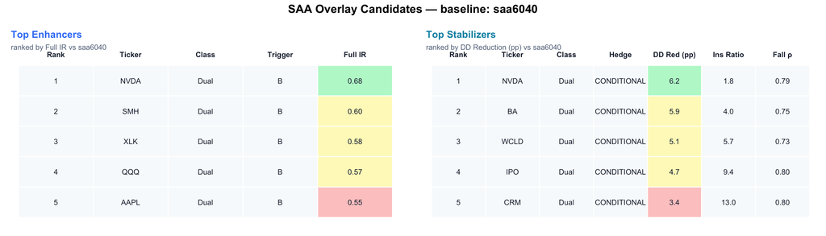

```r
print(res$summary_fig)
```

**Reading the table:**

- **Enhancers** are ranked by `full_ir` — the annualised excess return per unit of tracking error vs the SAA. Positive IR means the ticker beat the SAA on a risk-adjusted basis over the full history.
- **Stabilizers** are ranked by `dd_reduction` (in pp) — how many percentage points of MaxDD the SAA loses when 10% of the portfolio is replaced by the candidate. `Ins Ratio` = DD reduction / return drag; higher = cheaper insurance.
- **Hedge type:**
  - `FULL` — Fall correlation ≤ −0.10: true crisis hedge, rallies when SAA falls.
  - `PARTIAL` — Fall correlation between −0.10 and +0.30: uncorrelated in Falls.
  - `CONDITIONAL` — Fall correlation > +0.30: improves DD only through portfolio maths.

## 5.3 Enhancer raw rankings

```r
res$enhancers[, c("ticker","classification","trigger_type","full_ir","fall_corr","n_days")]
```

| ticker | classification | trigger_type | full_ir | fall_corr | n_days |
| --- | --- | --- | --- | --- | --- |
| NVDA | Dual | B | 0.68 | 0.79 | 2073 |
| SMH | Dual | B | 0.60 | 0.89 | 2073 |
| XLK | Dual | B | 0.58 | 0.95 | 2073 |
| QQQ | Dual | B | 0.57 | 0.95 | 2073 |
| AAPL | Dual | B | 0.55 | 0.89 | 2073 |

## 5.4 Stabilizer raw rankings

```r
res$stabilizers[, c("ticker","classification","hedge_type","dd_reduction","ins_ratio","fall_corr")]
```

| ticker | classification | hedge_type | dd_reduction | ins_ratio | fall_corr |
| --- | --- | --- | --- | --- | --- |
| NVDA | Dual | CONDITIONAL | 6.2 | 1.76 | 0.79 |
| BA | Dual | CONDITIONAL | 5.9 | 3.95 | 0.75 |
| WCLD | Dual | CONDITIONAL | 5.1 | 5.73 | 0.73 |
| IPO | Dual | CONDITIONAL | 4.7 | 9.39 | 0.80 |
| CRM | Dual | CONDITIONAL | 3.4 | 12.96 | 0.80 |

# 6 Enhancer Backtest

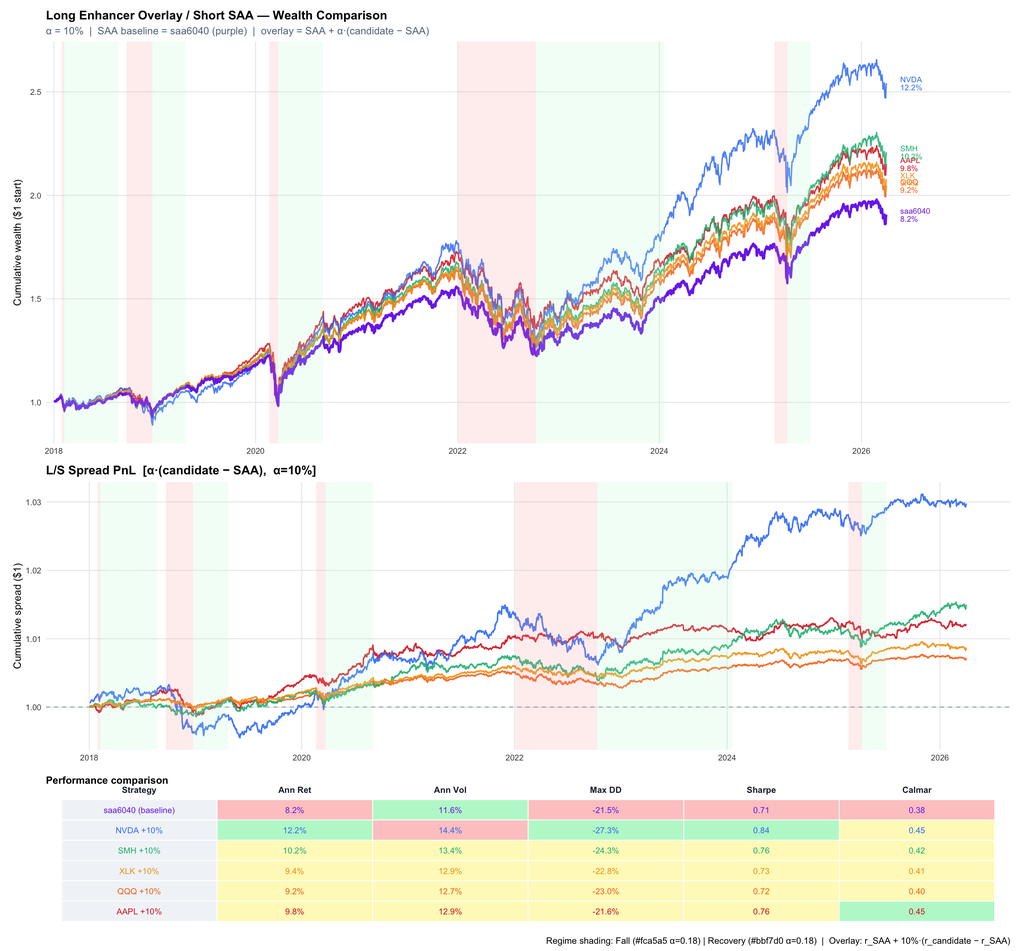

```r
print(res$enh_backtest$fig)
```

**Stats table:**

```r
res$enh_backtest$stats %>%
  dplyr::mutate(
    `Ann Ret` = sprintf("%.1f%%", `Ann Ret` * 100),
    `Ann Vol` = sprintf("%.1f%%", `Ann Vol` * 100),
    `Max DD`  = sprintf("%.1f%%", `Max DD`  * 100)
  )
```

| Strategy | Ann Ret | Ann Vol | Max DD | Sharpe | Calmar |
| --- | --- | --- | --- | --- | --- |
| saa6040 (baseline) | 8.2% | 11.6% | -21.5% | 0.707 | 0.382 |
| NVDA +10% | 12.2% | 14.4% | -27.3% | 0.843 | 0.445 |
| SMH +10% | 10.2% | 13.4% | -24.3% | 0.760 | 0.419 |
| XLK +10% | 9.4% | 12.9% | -22.8% | 0.726 | 0.411 |
| QQQ +10% | 9.2% | 12.7% | -23.0% | 0.721 | 0.399 |
| AAPL +10% | 9.8% | 12.9% | -21.6% | 0.759 | 0.453 |

# 7 Stabilizer Backtest

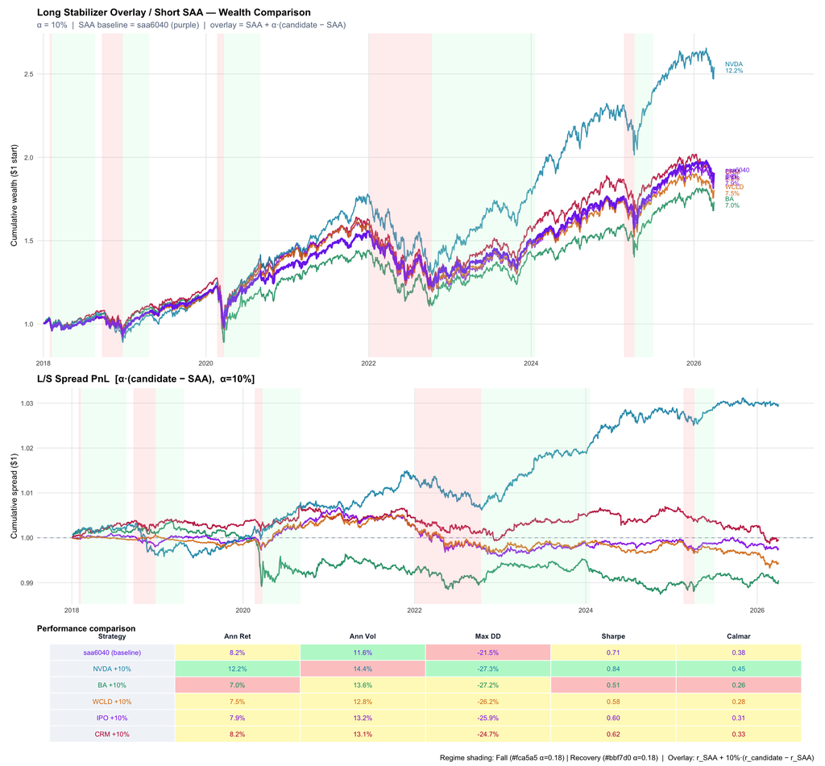

```r
print(res$stab_backtest$fig)
```

**Reading the figure:** Same structure as the enhancer figure. For stabilizers, the key panels are:

- **P1:** Does the overlay reduce drawdown in Fall regimes (red-shaded bands)?
- **P2:** Is the spread PnL roughly flat outside Falls (low drag in good times)?

The ideal stabilizer profile: spread hovers near zero in Consolidation/Recovery, then spikes sharply positive during Falls — insurance that costs little in calm markets.

**Stats table:**

```r
res$stab_backtest$stats %>%
  dplyr::mutate(
    `Ann Ret` = sprintf("%.1f%%", `Ann Ret` * 100),
    `Ann Vol` = sprintf("%.1f%%", `Ann Vol` * 100),
    `Max DD`  = sprintf("%.1f%%", `Max DD`  * 100)
  )
```

| Strategy | Ann Ret | Ann Vol | Max DD | Sharpe | Calmar |
| --- | --- | --- | --- | --- | --- |
| saa6040 (baseline) | 8.2% | 11.6% | -21.5% | 0.707 | 0.382 |
| NVDA +10% | 12.2% | 14.4% | -27.3% | 0.843 | 0.445 |
| BA +10% | 7.0% | 13.6% | -27.2% | 0.513 | 0.256 |
| WCLD +10% | 7.5% | 12.8% | -26.2% | 0.583 | 0.285 |
| IPO +10% | 7.9% | 13.2% | -25.9% | 0.602 | 0.306 |
| CRM +10% | 8.2% | 13.1% | -24.7% | 0.622 | 0.330 |

# 8 Fingerprints

When `print_fingerprints = TRUE`, each candidate generates a 7-panel `screen_ticker()` fingerprint:

| Panel | Content |
| --- | --- |
| P1 | Wealth: ticker vs SAA |
| P2 | L/S spread: ticker minus SAA (cumulative) |
| P3 | Drawdown comparison |
| P4 | Return distribution |
| P5 | Rolling 63-day correlation with SAA |
| P6 | Regime-conditional correlation (Fall / Recovery / Consolidation) |
| P7 | Rolling 63-day information ratio |

```r
# Access individual fingerprints after running with print_fingerprints = TRUE
res2 <- run_saa_overlay_workflow("SPY", "IEF", w1 = 0.60, print_fingerprints = TRUE)
res2$enh_screens[["GLD"]]$plot       # 7-panel fingerprint for GLD
res2$enh_screens[["GLD"]]$enhancer   # enhancer verdict + scores
res2$stab_screens[["TLT"]]$stabilizer  # stabilizer verdict + dd metrics
```

# 9 Advanced Usage

## 9.1 Custom universe

Restrict classification to a thematic subset:

```r
equity_hedges <- c("GLD","SLV","BIL","SHY","TLT","BNDX","VXX","DBMF")

res_eq <- run_saa_overlay_workflow(
  ticker1  = "SPY", ticker2 = "IEF", w1 = 0.60,
  universe = equity_hedges,
  enh_pct  = 0.10, stab_pct = 0.10,
  print_fingerprints = FALSE
)
```

## 9.2 Different SAA pairs

The workflow is pair-agnostic. Any two tickers in `xts_ret` work:

```r
# Growth / bond
res_qqq <- run_saa_overlay_workflow("QQQ", "AGG", w1 = 0.65)

# International equity / gold
res_intl <- run_saa_overlay_workflow("URTH", "GLD", w1 = 0.70)
```

Each call creates a new named column in `xts_ret` (e.g. `"saa6535"`, `"saa7030"`), so multiple SAA variants can coexist.

## 9.3 Varying α

To compare overlay sizes, run `backtest_ls_overlay()` directly:

```r
for (alpha in c(0.05, 0.10, 0.15, 0.20)) {
  bt <- backtest_ls_overlay(
    saa_name = "saa6040",
    tickers  = res$enhancers$ticker,
    pct      = alpha,
    type     = "enhancer"
  )
  print(bt$fig)
}
```

## 9.4 Accessing the classification table

`rank_enhancers()` and `rank_stabilizers()` return only the top N rows. To see the full table:

```r
source(here("scripts_daa_saa_taa/screen_ticker.R"))
full_cls <- classify_universe(
  baseline  = "saa6040",
  xts_ret   = xts_ret,
  rt        = rt,
  overlay_w = 0.10,
  verbose   = TRUE
)
# All tickers with their classification, full_ir, dd_reduction, ins_ratio, etc.
```

# 10 Interpretation Guide

## What makes a good enhancer?

An enhancer consistently beats the SAA on a risk-adjusted basis across all three regimes. The strongest enhancers show:

- `full_ir > 0.3` — meaningful outperformance per unit of tracking risk
- `trigger_type = "ALPHA"` — both the candidate and SAA rise, but the candidate rises more (Consolidation/Recovery leadership)
- Fall excess ≥ 0 — doesn’t underperform significantly during drawdowns

> High `full_ir` with negative Fall excess is an *enhancer in good times only* — valuable for return but adds risk concentration at the worst moment.

## What makes a good stabilizer?

A stabilizer reduces the SAA’s MaxDD at low cost to return. The strongest stabilizers show:

- `dd_reduction > 2pp` — meaningful drawdown protection at 10% overlay
- `ins_ratio > 5` — each pp of return drag buys ≥5pp of DD reduction
- `fall_corr < 0` — genuinely negatively correlated with SAA during Falls (`FULL` hedge)
- Spread PnL: flat in calm periods, positive spikes during Falls

> `CONDITIONAL` hedge types improve DD only through portfolio variance maths (low correlation but positive Fall correlation) — cheaper but less reliable during crisis episodes than `FULL` hedges.

## Decision table

| Objective | Primary metric | Secondary metric |
| --- | --- | --- |
| Add return without increasing risk | `full_ir` | Sharpe vs SAA baseline |
| Reduce worst drawdown | `dd_reduction` | `ins_ratio` |
| Reduce tail loss | `CVaR 5%` improvement | `fall_corr` |
| Cheapest insurance | `ins_ratio` | `return_drag` |
| Regime-aware protection | `hedge_type = FULL` | `fall_corr` < −0.10 |

*Source: `scripts_daa_saa_taa/saa_overlay_workflow.R`* *Classification via `classify_universe()` in `screen_ticker.R`* *Fingerprints via `screen_ticker()` in `screen_ticker.R`* *Regime shading via `build_regime_table()` with T_FALL = 10%*